# Assignment 8

Tiger

May 15, 2018

# T-Test

## 1)Is there adifferense in mean value between your sector and “the rest” forthe group’s designated variable?

we run t-test to compare the difference

```r
alldata=c(8,8,5,8,6,4,6,5,8,8,4,8,1,7,6,6,7,8,8,3,7,5,5,5,7,8,6,7,8,7,3,6,6,5,8,7,5,8,5,6)
group5=c(6,6,7,8,8,3)
alldatayes=c(8,8,5,8,6,4,5,8,4,8,1,6,6,7,8,8,3,7,5,5,7,8,7,6,6,5,8,7,8,5)
alldatano=c(6,8,7,5,7,8,6,3,5,6)
alldataman=c(8,8,5,6,6,5,8,8,4,8,7,6,6,7,8,8,3,7,5,5,5,7,8,6,7,8,7,3,6,8,7,8)
alldatawoman=c(8,4,1,6,5,5,6)
t.test(alldata,group5)
```

```
##
##  Welch Two Sample t-test
##
## data:  alldata and group5
## t = -0.1654, df = 6.3122, p-value = 0.8738
## alternative hypothesis: true difference in means is not equal to 0
## 95 percent confidence interval:
##  -2.082427  1.815761
## sample estimates:
## mean of x mean of y
##  6.200000  6.333333
```

The p-value of t-test is 0.8738, and the mean are 6.2 and 6.33, which means there is no significate difference.

## 2) Is there a differense in mean value between those with a strategy (Q20) compared with those that do not have a strategy for the group’s designated variable?

```r
t.test(alldatayes,alldatano)
```

```
##
##  Welch Two Sample t-test
##
## data:  alldatayes and alldatano
## t = 0.2296, df = 17.848, p-value = 0.821
## alternative hypothesis: true difference in means is not equal to 0
## 95 percent confidence interval:
##  -1.087469  1.354136
## sample estimates:
## mean of x mean of y
##  6.233333  6.100000
```

The p-value is 0.821, and the mean of each group are 6.233 and 6.1, which indicates that there is no significate difference.

## 3)s there a differensein mean valuebetween between men and women (Q5) forthe group’s designated variable?

We don’t use the data from the “self-defined” respondent in this quesitons.

```r
t.test(alldataman,alldatawoman)
```

```
##
##  Welch Two Sample t-test
##
## data:  alldataman and alldatawoman
## t = 1.747, df = 7.3215, p-value = 0.1223
## alternative hypothesis: true difference in means is not equal to 0
## 95 percent confidence interval:
##  -0.512383  3.512383
## sample estimates:
## mean of x mean of y
##       6.5       5.0
```

the means of x is 6.5, while y is 5.0, there is mean difference. Howeve the p-value of the t-test is 0.1223, which indicates there is no difference.

# 2 ANOVA

## Please answer if there is a differencein mean valuebetween the sectors (compare the mean value of 1, 2, and 3)for the group’s designated variable:

## first, we did the Anova, and then we did noramlity test.

```r
groupPublic=c(6,2,8)
groupHealthcare=c(5,8,8)
groupEducation=c(4,5,8,2)
group1=c(groupPublic,groupHealthcare,groupEducation)

groupManufacturing=c(7,6,8,7,4)
groupConsturction=c(8,8,8,8,6)
groupTransport=c(7,7,6)
group2=c(groupManufacturing,groupConsturction,groupTransport)

groupFinance=c(6,8)
groupPro=c(7,6,8,7,5)
groupICT=c(5,4,7,8,8,5)
group3=c(groupFinance,groupPro,groupICT)

groupnum= c(rep(1,10),rep(2,13),rep(3,13))
g=c(groupHealthcare,groupPublic,groupEducation,groupManufacturing,groupConsturction,groupTransport,groupFinance,groupPro,groupICT)
test=data.frame(g=c(groupHealthcare,groupPublic,groupEducation,groupManufacturing,groupConsturction,groupTransport,groupFinance,groupPro,groupICT),groupnumber=factor(groupnum))
fit=aov(g~groupnumber,data=test)
shapiro.test(g)
```

```
##
##  Shapiro-Wilk normality test
##
## data:  g
## W = 0.84855, p-value = 0.0001763
```

```r
summary(fit)
```

```
##             Df Sum Sq Mean Sq F value Pr(>F)
## groupnumber  2  10.00   5.001   1.783  0.184
## Residuals   33  92.55   2.805
```

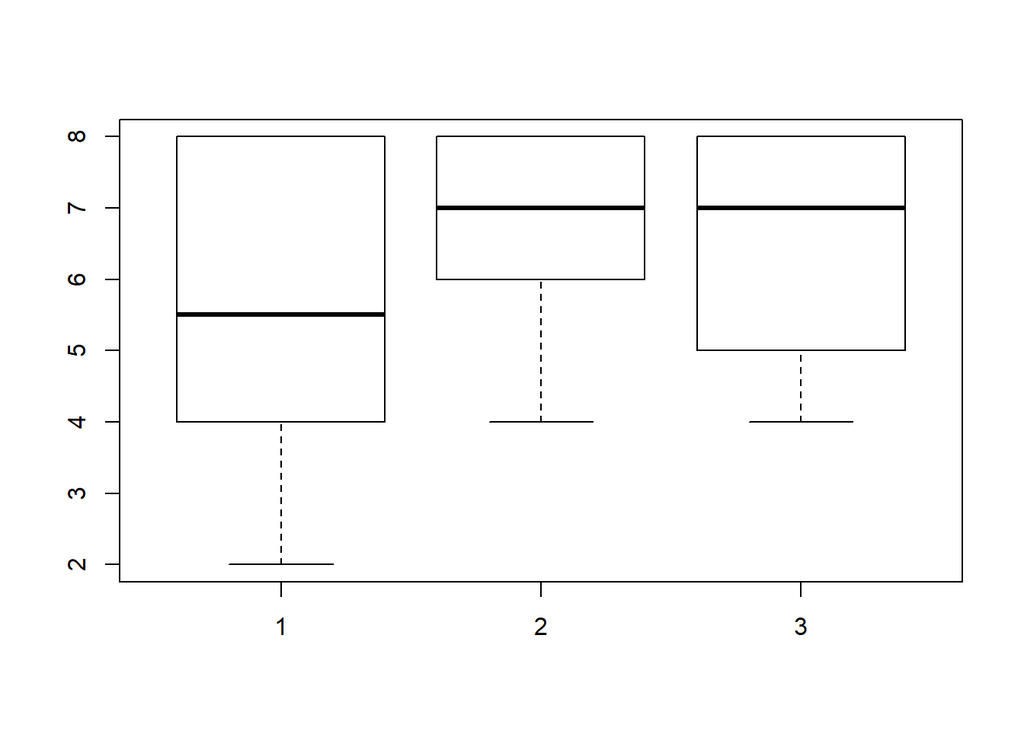

```r
boxplot(group1,group2,group3)
```

```r
mean(group1)
```

```
## [1] 5.6
```

```r
mean(group2)
```

```
## [1] 6.923077
```

```r
mean(group3)
```

```
## [1] 6.461538
```

# Regression

## Please answer if there is a significant relationship between any of the independent variables and the dependent variable for the group.

```r
gender=c(1,1,1,2,1,2,1,1,1,1,1,1,2,1,1,1,1,1,1,1,1,1,1,1,1,1,1,1,1,1,1,1,2,1,3,1,1,2,1,2,2)
Q20=c(1,1,1,1,1,1,0,1,0,1,1,1,1,0,1,1,1,1,1,1,1,1,1,0,0,0,0,1,0,1,1,0,1,1,1,1,1,0,1,1,0)
Q21=c(1,1,1,1,0,0,0,0,0,1,0,1,0,0,1,1,1,1,1,0,0,1,1,0,0,0,0,1,0,1,0,0,0,0,1,1,1,0,1,1,0)
Q22=c(8,8,7,7,6,2,4,3,1,8,8,4,3,4,7,4,7,8,8,5,2,7,5,4,3,7,2,6,5,8,5,2,3,8,8,6,5,1,6,5,4)
Q35=c(8,6,8,8,5,1,4,7,8,8,7,6,3,8,1,3,8,8,8,3,7,6,4,5,5,6,5,7,5,8,7,2,3,3,7,1,5,8,6,1,7)
sector=c(1,1,1,1,1,2,2,2,2,3,3,4,4,4,5,5,5,5,5,5,6,6,6,6,6,7,7,7,7,7,8,8,8,9,9,9,9,9,10,10,10)

tryout=lm(Q35~sector+gender+Q20+Q21+Q22)
summary(tryout)
```

```
##
## Call:
## lm(formula = Q35 ~ sector + gender + Q20 + Q21 + Q22)
##
## Residuals:
##     Min      1Q  Median      3Q     Max
## -5.0594 -1.2938  0.5194  1.5964  3.5971
##
## Coefficients:
##             Estimate Std. Error t value Pr(>|t|)
## (Intercept)   5.7767     1.5362   3.760  0.00062 ***
## sector       -0.2226     0.1304  -1.707  0.09663 .
## gender        0.1424     0.7818   0.182  0.85648
## Q20          -1.8428     1.0300  -1.789  0.08224 .
## Q21           0.6860     0.9762   0.703  0.48689
## Q22           0.3443     0.2109   1.632  0.11159
## ---
## Signif. codes:  0 '***' 0.001 '**' 0.01 '*' 0.05 '.' 0.1 ' ' 1
##
## Residual standard error: 2.232 on 35 degrees of freedom
## Multiple R-squared:  0.1933, Adjusted R-squared:  0.07808
## F-statistic: 1.678 on 5 and 35 DF,  p-value: 0.1658
```

y= -0.2226*sector+0.1424*gender+ -1.8428*Q20+ 0.6860*Q21+0.3443*Q22+5.7767 As all the probability is more than 0.05, so there is actually no linear relationship between Y and any independent variables. Still we remember the Mean of Q35 is almost 6, so the intercept can represent the line.